# Copula Processes with V-Transforms

Alexander J. McNeil and Martin Bladt

2022-05-07

All types of copula process can be combined with a v-transform to model volatile time series.

## 1. VT-ARMA Copula Processes

VT-ARMA processes are created by adding a v-transform to an armacopula process using the command `vtscopula`. The generic commands `sim`, `fit` and `plot` also work for these processes.

### VT-ARMA(1,1) Example

This example uses a ARMA(1,1) copula and an off-centre linear v-transform. We set up the model and generate some data.

```r
vtarma11 <- vtscopula(armacopula(list(ar = 0.95, ma = -0.85)),
  Vtransform = Vlinear(delta = 0.6))
vtarma11
```

```
#> object class: vtscopula
#> ____________
#> Base copula:
#> object class: armacopula
#> name: ARMA(1,1)
#> parameters:
#>   ar1   ma1
#>  0.95 -0.85
#> ____________
#> V-transform:
#> name: Vlinear
#> parameters:
#> delta
#>   0.6
```

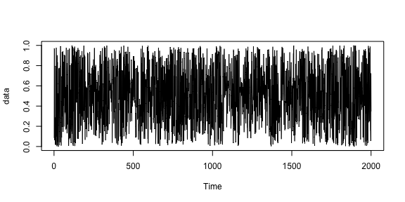

```r
set.seed(19)
data <- sim(vtarma11, 2000)
ts.plot(data)
```

We now fit the model with a fixed value for the fulcrum parameter $\delta$ and plot the results. (More on fulcrum choice next.)

```r
vtarma11spec <- vtscopula(armacopula(list(ar = 0, ma = 0)), Vtransform = Vlinear(delta = 0.6))
vtarma11fit <- fit(vtarma11spec, data)
vtarma11fit
```

```
#> object class: vtscopula
#> ____________
#> Base copula:
#> object class: armacopula
#> name: ARMA(1,1)
#> parameters:
#>        ar1        ma1
#>  0.9538201 -0.8531713
#> ____________
#> V-transform:
#> name: Vlinear
#> parameters:
#> delta
#>   0.6
#> _____________________
#> Summary of estimates:
#>     ar.ar1     ma.ma1
#>  0.9538201 -0.8531713
#> convergence status: 0, log-likelihood: 102.2355
```

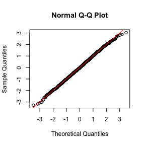

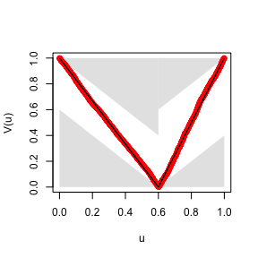

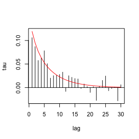

```r
plot(vtarma11fit)
plot(vtarma11fit, plottype = "vtransform")
plot(vtarma11fit, plottype = "kendall" )
```

Optimization over the fulcrum parameter $\delta$ does not take place. To identify a reasonable value for $\delta$ we can carry a profile likelihood analysis using different fixed values for the fulcrum parameter.

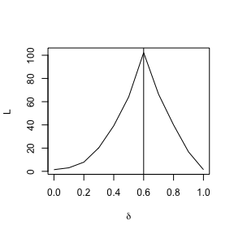

```r
profilefulcrum(data, tscopula = vtarma11spec, locations = seq(from = 0, to = 1, length = 11))
abline(v = 0.6)
```

## 2. VT-D-Vine Copula Processes (type 2)

VT-D-Vine processes are created by adding a v-transform to an `dvinecopula2` object using the command `vtscopula`. The generic commands `sim`, `fit` and `plot` also work for these processes.

### Construction

We add a 2-parameter V-transform.

```r
copmod <- dvinecopula2(family = "joe",
                       kpacf = "kpacf_arma",
                       pars = list(ar = 0.9, ma = -0.85),
                       maxlag = 20)
vcopmod <- vtscopula(copmod,
  Vtransform = V2p(delta = 0.6, kappa = 0.8)
)
vcopmod
```

```
#> object class: vtscopula
#> ____________
#> Base copula:
#> object class: dvinecopula2
#> name: type2-d-vine
#> copula family: joe
#> KPACF: kpacf_arma with max lag 20
#> parameters:
#>    ar    ma
#>  0.90 -0.85
#> ____________
#> V-transform:
#> name: V2p
#> parameters:
#> delta kappa
#>   0.6   0.8
```

### Simulation

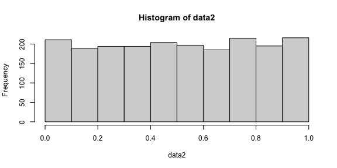

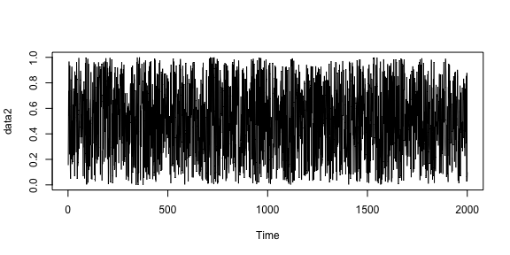

```r
set.seed(13)
data2 <- sim(vcopmod, n = 2000)
hist(data2)
ts.plot(data2)
```

### Estimation

```r
copspec_Joe <- dvinecopula2(family = "joe",
                            pars = list(ar = 0, ma = 0),
                            maxlag = 30)
vcopspec <- vtscopula(copspec_Joe, V2p(delta = 0.6))
vcopfit <- fit(vcopspec, data2,
               tsoptions = list(hessian = TRUE),
               control = list(maxit = 1000))
vcopfit
```

```
#> object class: vtscopula
#> ____________
#> Base copula:
#> object class: dvinecopula2
#> name: type2-d-vine
#> copula family: joe
#> KPACF: kpacf_arma with max lag 30
#> parameters:
#>         ar         ma
#>  0.8973846 -0.8434568
#> ____________
#> V-transform:
#> name: V2p
#> parameters:
#>     delta     kappa
#> 0.6000000 0.7743815
#> _____________________
#> Summary of estimates:
#>             ar          ma   vt.kappa
#> par 0.89738462 -0.84345681 0.77438147
#> se  0.01948549  0.02531814 0.06339235
#> convergence status: 0, log-likelihood: 48.57659
```

```r
coef(vcopfit)
```

```
#>         ar         ma      delta      kappa
#>  0.8973846 -0.8434568  0.6000000  0.7743815
```

```r
coef(vcopmod)
```

```
#>    ar    ma delta kappa
#>  0.90 -0.85  0.60  0.80
```

### Plotting

We can plot the estimated v-transform and well as the goodness-of-fit plots for the `dvinecopula2` object based on Kendall rank correlations.

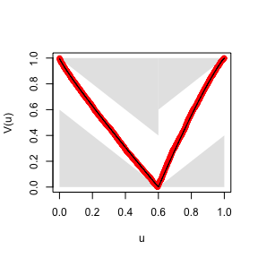

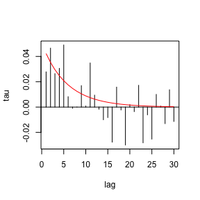

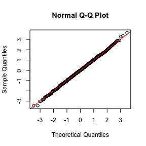

```r
plot(vcopfit, plottype = "vtransform")
plot(vcopfit, plottype = "kendall")
plot(vcopfit, plottype = "residual")
```